# R Notebook

Protein - process to add SYMBOL NAMES -

```r
library(readxl)
library(dplyr)
```

Read in the files proteomics

```r
df.bright <- read_excel("/Users/rhalenathomas/Downloads/Move_Data/DarkGenomeResult/FromRoxanneProteomics/Files/BrightGenome_TMT_2022_Roxanne_6_weeks.xlsx",col_names = TRUE)

colnames(df.bright)
```

```
 [1] "Checked"
 [2] "Protein FDR Confidence: Combined"
 [3] "Master"
 [4] "Accession"
 [5] "Description"
 [6] "Abundance Ratio (log2): (A53T_6_weeks) / (AIW_6_weeks)"
 [7] "Abundance Ratio (log2): (GBA_6_weeks) / (AIW_6_weeks)"
 [8] "Abundance Ratio (log2): (PINK1_6_weeks) / (AIW_6_weeks)"
 [9] "Abundance Ratio (log2): (PRKN_6_weeks) / (AIW_6_weeks)"
[10] "Abundance Ratio P-Value: (A53T_6_weeks) / (AIW_6_weeks)"
[11] "Abundance Ratio P-Value: (GBA_6_weeks) / (AIW_6_weeks)"
[12] "Abundance Ratio P-Value: (PINK1_6_weeks) / (AIW_6_weeks)"
[13] "Abundance Ratio P-Value: (PRKN_6_weeks) / (AIW_6_weeks)"
[14] "Abundances (Grouped) CV [%]: A53T_6_weeks"
[15] "Abundances (Grouped) CV [%]: AIW_6_weeks"
```

[output cut: 21 more lines]

Example of description

```r
df.bright$Description[1:3]
```

```
[1] "Mitochondrial chaperone BCS1 OS=Homo sapiens OX=9606 GN=BCS1L PE=1 SV=1"
[2] "Guanine nucleotide-binding protein G(i) subunit alpha-3 OS=Homo sapiens OX=9606 GN=GNAI3 PE=1 SV=3"
[3] "Neuronal pentraxin receptor OS=Homo sapiens OX=9606 GN=NPTXR PE=1 SV=1"
```

Extract symbol from description

```r
# Extract the GN value from the Description column
df.bright$Gene <- sub(".*GN=([^ ]+).*", "\\1", df.bright$Description)

# Replace any values in Symbol that did not have a GN entry with NA
df.bright$Gene[!grepl("GN=", df.bright$Description)] <- NA

# View the updated dataframe
head(df.bright[, c("Description", "Gene")])
```

| Description | Gene |
| --- | --- |
| Mitochondrial chaperone BCS1 OS=Homo sapiens OX=9606 GN=BCS1L PE=1 SV=1 | BCS1L |
| Guanine nucleotide-binding protein G(i) subunit alpha-3 OS=Homo sapiens OX=9606 GN=GNAI3 PE=1 SV=3 | GNAI3 |
| Neuronal pentraxin receptor OS=Homo sapiens OX=9606 GN=NPTXR PE=1 SV=1 | NPTXR |
| Calsyntenin-2 OS=Homo sapiens OX=9606 GN=CLSTN2 PE=1 SV=2 | CLSTN2 |
| Synaptic vesicle glycoprotein 2C OS=Homo sapiens OX=9606 GN=SV2C PE=1 SV=1 | SV2C |
| Visinin-like protein 1 OS=Homo sapiens OX=9606 GN=VSNL1 PE=1 SV=2 | VSNL1 |

```r
NA
NA
NA
```

```r
# Count the number of NA values in the Symbol column
na_count <- sum(is.na(df.bright$Gene))

# Print the result
print(na_count)
```

```
[1] 16
```

Convert Accession numbers to SYMBOLS

```r
#if (!require("BiocManager", quietly = TRUE))
#    install.packages("BiocManager")
#BiocManager::install("mygene")

library(mygene)

# Query using mygene

accessions <- df.bright$Accession
result <- queryMany(accessions, scopes = "uniprot", fields = c("symbol"), species = "human", returnall = FALSE)
```

```
Querying chunk 1
Querying chunk 2
Querying chunk 3
Querying chunk 4
Querying chunk 5
```

```
Finished
Pass returnall=TRUE to return lists of duplicate or missing query terms.
```

```r
names.df <- as.data.frame(result)

dim(names.df)
```

```
[1] 4154    5
```

```r
dim(df.bright)
```

```
[1] 4111   39
```

```r
# extra values are added in the conversion
# add the values back into the dataframe matching Accession and query

df1 <- df.bright

# Merge df1 and names.df by Accession and query, keeping all rows from df1
merged_df.b <- merge(df1, names.df[, c("query", "symbol")], by.x = "Accession", by.y = "query", all.x = TRUE)

# Create a new column "Symbol" in df1 based on the merged results
merged_df.b <- merged_df.b %>%
  mutate(Symbol = ifelse(is.na(symbol), Accession, symbol))


colnames(merged_df.b)
```

```
 [1] "Accession"
 [2] "Checked"
 [3] "Protein FDR Confidence: Combined"
 [4] "Master"
 [5] "Description"
 [6] "Abundance Ratio (log2): (A53T_6_weeks) / (AIW_6_weeks)"
 [7] "Abundance Ratio (log2): (GBA_6_weeks) / (AIW_6_weeks)"
 [8] "Abundance Ratio (log2): (PINK1_6_weeks) / (AIW_6_weeks)"
 [9] "Abundance Ratio (log2): (PRKN_6_weeks) / (AIW_6_weeks)"
[10] "Abundance Ratio P-Value: (A53T_6_weeks) / (AIW_6_weeks)"
[11] "Abundance Ratio P-Value: (GBA_6_weeks) / (AIW_6_weeks)"
[12] "Abundance Ratio P-Value: (PINK1_6_weeks) / (AIW_6_weeks)"
[13] "Abundance Ratio P-Value: (PRKN_6_weeks) / (AIW_6_weeks)"
[14] "Abundances (Grouped) CV [%]: A53T_6_weeks"
[15] "Abundances (Grouped) CV [%]: AIW_6_weeks"
```

[output cut: 25 more lines]

```r
# Count the number of NA values in the Symbol column
na_count <- sum(is.na(merged_df.b$symbol))

# Print the result
print(na_count)
```

```
[1] 111
```

Check if there are some with symbol but no gene name

```r
# Count the number of NA values in the Symbol column
na_count <- sum(is.na(merged_df.b$symbol)&(is.na(merged_df.b$Gene)))

# Print the result
print(na_count)
```

```
[1] 16
```

```r
# see if the symbol and genes are matching


head(merged_df.b[, c("Description", "Gene", "symbol")],10)
```

|  | Description | Gene | symbol |
| --- | --- | --- | --- |
| 1 | High density lipoprotein binding protein (Vigilin), isoform CRA_a OS=Homo sapiens OX=9606 GN=HDLBP PE=1 SV=1 | HDLBP | HDLBP |
| 2 | EH domain-containing protein 1 OS=Homo sapiens OX=9606 GN=EHD1 PE=1 SV=1 | EHD1 | EHD1 |
| 3 | BCL2-associated athanogene 6 OS=Homo sapiens OX=9606 GN=BAG6 PE=1 SV=1 | BAG6 | NA |
| 4 | E3 ubiquitin-protein ligase NOSIP (Fragment) OS=Homo sapiens OX=9606 GN=NOSIP PE=1 SV=1 | NOSIP | NOSIP |
| 5 | Desmuslin, isoform CRA_a OS=Homo sapiens OX=9606 GN=SYNM PE=1 SV=1 | SYNM | SYNM |
| 6 | Amyloid-beta A4 precursor protein-binding family B member 1 OS=Homo sapiens OX=9606 GN=APBB1 PE=1 SV=7 | APBB1 | APBB1 |
| 7 | Putative monooxygenase p33MONOX OS=Homo sapiens OX=9606 GN=KIAA1191 PE=1 SV=1 | KIAA1191 | KIAA1191 |
| 8 | Heme oxygenase (biliverdin-producing) OS=Homo sapiens OX=9606 GN=HMOX2 PE=1 SV=1 | HMOX2 | HMOX2 |
| 9 | GRIP1-associated protein 1 OS=Homo sapiens OX=9606 GN=GRIPAP1 PE=1 SV=1 | GRIPAP1 | GRIPAP1 |
| 10 | Translation initiation factor eIF-2B subunit delta OS=Homo sapiens OX=9606 GN=EIF2B4 PE=1 SV=1 | EIF2B4 | NA |

```r
NA
```

Symbol appears the same as gene and is not needed

```r
# Filter rows where either Symbol or Gene is NA
filtered_df <- merged_df.b[!is.na(merged_df.b$symbol) & !is.na(merged_df.b$Gene), ]

# Create a dataframe of rows where Symbol and Gene don't match
mismatch_df <- filtered_df[filtered_df$symbol != filtered_df$Gene, ]

dim(mismatch_df)
```

```
[1] 67 40
```

```r
# View the result
head(mismatch_df[, c("Description", "Gene", "symbol")],10)
```

|  | Description | Gene | symbol |
| --- | --- | --- | --- |
| 87 | Arpin OS=Homo sapiens OX=9606 GN=C15orf38-AP3S2 PE=3 SV=1 | C15orf38-AP3S2 | ARPIN-AP3S2 |
| 90 | BLOC-1-related complex subunit 7 OS=Homo sapiens OX=9606 GN=BORCS7-ASMT PE=3 SV=1 | BORCS7-ASMT | BORCS7 |
| 93 | Putative glutamine amidotransferase-like class 1 domain-containing protein 3B, mitochondrial OS=Homo sapiens OX=9606 GN=GATD3B PE=5 SV=1 | GATD3B | GATD3 |
| 120 | Heat shock 70 kDa protein 1B OS=Homo sapiens OX=9606 GN=HSPA1B PE=1 SV=1 | HSPA1B | HSPA1A |
| 311 | Vesicle-fusing ATPase OS=Homo sapiens OX=9606 GN=SPATA5 PE=1 SV=1 | SPATA5 | AFG2A |
| 360 | Transmembrane protein KIAA1109 OS=Homo sapiens OX=9606 GN=KIAA1109 PE=1 SV=1 | KIAA1109 | BLTP1 |
| 725 | C4a anaphylatoxin OS=Homo sapiens OX=9606 GN=C4B PE=1 SV=1 | C4B | C4B_2 |
| 844 | Casein kinase I isoform epsilon (Fragment) OS=Homo sapiens OX=9606 GN=CSNK1E PE=1 SV=1 | CSNK1E | TPTEP2-CSNK1E |
| 864 | Spermatogenesis-associated protein 5-like protein 1 (Fragment) OS=Homo sapiens OX=9606 GN=SPATA5L1 PE=1 SV=1 | SPATA5L1 | AFG2B |
| 995 | D-dopachrome decarboxylase OS=Homo sapiens OX=9606 GN=DDT PE=1 SV=1 | DDT | DDTL |

Looks like 67 proteins do not match the gene names.

I will keep the gene names and make a note here

```r
# Extract the GN value from the Description column
df.bright$Symbol <- sub(".*GN=([^ ]+).*", "\\1", df.bright$Description)

# Replace NA values in the Symbol column with corresponding Accession values
df.bright$Symbol[!grepl("GN=", df.bright$Description)] <- df.bright$Accession[!grepl("GN=", df.bright$Description)]

# View the updated dataframe
head(df.bright[, c("Accession", "Description", "Symbol")])
```

| Accession | Description | Symbol |
| --- | --- | --- |
| Q9Y276 | Mitochondrial chaperone BCS1 OS=Homo sapiens OX=9606 GN=BCS1L PE=1 SV=1 | BCS1L |
| P08754 | Guanine nucleotide-binding protein G(i) subunit alpha-3 OS=Homo sapiens OX=9606 GN=GNAI3 PE=1 SV=3 | GNAI3 |
| A0A1X7SBT7 | Neuronal pentraxin receptor OS=Homo sapiens OX=9606 GN=NPTXR PE=1 SV=1 | NPTXR |
| Q9H4D0 | Calsyntenin-2 OS=Homo sapiens OX=9606 GN=CLSTN2 PE=1 SV=2 | CLSTN2 |
| Q496J9 | Synaptic vesicle glycoprotein 2C OS=Homo sapiens OX=9606 GN=SV2C PE=1 SV=1 | SV2C |
| P62760 | Visinin-like protein 1 OS=Homo sapiens OX=9606 GN=VSNL1 PE=1 SV=2 | VSNL1 |

```r
NA
NA
```

Check if there are 16 values where the accession is they symbol

```r
# Count the number of rows where Accession is equal to Symbol
matching_count <- sum(df.bright$Accession == df.bright$Symbol)

# Print the result
print(matching_count)
```

```
[1] 16
```

Now df.bright has Symbol for all entries

```r
colnames(df.bright)
```

```
 [1] "Checked"
 [2] "Protein FDR Confidence: Combined"
 [3] "Master"
 [4] "Accession"
 [5] "Description"
 [6] "Abundance Ratio (log2): (A53T_6_weeks) / (AIW_6_weeks)"
 [7] "Abundance Ratio (log2): (GBA_6_weeks) / (AIW_6_weeks)"
 [8] "Abundance Ratio (log2): (PINK1_6_weeks) / (AIW_6_weeks)"
 [9] "Abundance Ratio (log2): (PRKN_6_weeks) / (AIW_6_weeks)"
[10] "Abundance Ratio P-Value: (A53T_6_weeks) / (AIW_6_weeks)"
[11] "Abundance Ratio P-Value: (GBA_6_weeks) / (AIW_6_weeks)"
[12] "Abundance Ratio P-Value: (PINK1_6_weeks) / (AIW_6_weeks)"
[13] "Abundance Ratio P-Value: (PRKN_6_weeks) / (AIW_6_weeks)"
[14] "Abundances (Grouped) CV [%]: A53T_6_weeks"
[15] "Abundances (Grouped) CV [%]: AIW_6_weeks"
```

[output cut: 24 more lines]

Selected the desired columns for saving further analysis

Logfold change and pvalues for each line vs control

```r
df.dpe.b <- df.bright[, c(4,37,5:19)]
colnames(df.dpe.b)
```

```
 [1] "Accession"                                                "Symbol"
 [3] "Description"                                              "Abundance Ratio (log2): (A53T_6_weeks) / (AIW_6_weeks)"
 [5] "Abundance Ratio (log2): (GBA_6_weeks) / (AIW_6_weeks)"    "Abundance Ratio (log2): (PINK1_6_weeks) / (AIW_6_weeks)"
 [7] "Abundance Ratio (log2): (PRKN_6_weeks) / (AIW_6_weeks)"   "Abundance Ratio P-Value: (A53T_6_weeks) / (AIW_6_weeks)"
 [9] "Abundance Ratio P-Value: (GBA_6_weeks) / (AIW_6_weeks)"   "Abundance Ratio P-Value: (PINK1_6_weeks) / (AIW_6_weeks)"
[11] "Abundance Ratio P-Value: (PRKN_6_weeks) / (AIW_6_weeks)"  "Abundances (Grouped) CV [%]: A53T_6_weeks"
[13] "Abundances (Grouped) CV [%]: AIW_6_weeks"                 "Abundances (Grouped) CV [%]: GBA_6_weeks"
[15] "Abundances (Grouped) CV [%]: PINK1_6_weeks"               "Abundances (Grouped) CV [%]: Pool"
[17] "Abundances (Grouped) CV [%]: PRKN_6_weeks"
```

Save the csv with the logfold change now with gene names accept for the 16 without gene names and will have accession numbers

```r
write.csv(df.dpe.b,"/Users/rhalenathomas/Downloads/Move_Data/DarkGenomeResult/ProtomicsDifferentialAbundance_bright_all.csv")

# make files for each gene vs control DPE  /DPE_files
```

All samples here are 6 weeks DA neurons

```r
df.dpe <- df.dpe.b

#a53t
df.t <- df.dpe[, c(1:3,4,8)]
colnames(df.t)
```

```
[1] "Accession"                                               "Symbol"
[3] "Description"                                             "Abundance Ratio (log2): (A53T_6_weeks) / (AIW_6_weeks)"
[5] "Abundance Ratio P-Value: (A53T_6_weeks) / (AIW_6_weeks)"
```

```r
colnames(df.t) <- c("Accession","Symbol","Description","log2_ratio","p-value")
head(df.t)
```

| Accession | Symbol | Description | log2_ratio | p-value |
| --- | --- | --- | --- | --- |
| Q9Y276 | BCS1L | Mitochondrial chaperone BCS1 OS=Homo sapiens OX=9606 GN=BCS1L PE=1 SV=1 | 6.64 | NA |
| P08754 | GNAI3 | Guanine nucleotide-binding protein G(i) subunit alpha-3 OS=Homo sapiens OX=9606 GN=GNAI3 PE=1 SV=3 | 6.64 | NA |
| A0A1X7SBT7 | NPTXR | Neuronal pentraxin receptor OS=Homo sapiens OX=9606 GN=NPTXR PE=1 SV=1 | 6.64 | NA |
| Q9H4D0 | CLSTN2 | Calsyntenin-2 OS=Homo sapiens OX=9606 GN=CLSTN2 PE=1 SV=2 | 6.64 | NA |
| Q496J9 | SV2C | Synaptic vesicle glycoprotein 2C OS=Homo sapiens OX=9606 GN=SV2C PE=1 SV=1 | 6.64 | NA |
| P62760 | VSNL1 | Visinin-like protein 1 OS=Homo sapiens OX=9606 GN=VSNL1 PE=1 SV=2 | 2.84 | 4.206266e-05 |

```r
write.csv(df.t,"/Users/rhalenathomas/Downloads/Move_Data/DarkGenomeResult/DPE_files2/SNCA-A53T_ProtomicsDifferentialAbundance.csv")

#GBA
df.t <- df.dpe[, c(1:3,5,9)]
colnames(df.t)
```

```
[1] "Accession"                                              "Symbol"
[3] "Description"                                            "Abundance Ratio (log2): (GBA_6_weeks) / (AIW_6_weeks)"
[5] "Abundance Ratio P-Value: (GBA_6_weeks) / (AIW_6_weeks)"
```

```r
colnames(df.t) <- c("Accession","Symbol","Description","log2_ratio","p-value")
head(df.t)
```

| Accession | Symbol | Description | log2_ratio | p-value |
| --- | --- | --- | --- | --- |
| Q9Y276 | BCS1L | Mitochondrial chaperone BCS1 OS=Homo sapiens OX=9606 GN=BCS1L PE=1 SV=1 | 6.64 | NA |
| P08754 | GNAI3 | Guanine nucleotide-binding protein G(i) subunit alpha-3 OS=Homo sapiens OX=9606 GN=GNAI3 PE=1 SV=3 | 6.64 | NA |
| A0A1X7SBT7 | NPTXR | Neuronal pentraxin receptor OS=Homo sapiens OX=9606 GN=NPTXR PE=1 SV=1 | 6.64 | NA |
| Q9H4D0 | CLSTN2 | Calsyntenin-2 OS=Homo sapiens OX=9606 GN=CLSTN2 PE=1 SV=2 | 6.64 | NA |
| Q496J9 | SV2C | Synaptic vesicle glycoprotein 2C OS=Homo sapiens OX=9606 GN=SV2C PE=1 SV=1 | 6.64 | NA |
| P62760 | VSNL1 | Visinin-like protein 1 OS=Homo sapiens OX=9606 GN=VSNL1 PE=1 SV=2 | 0.81 | 0.1602711 |

```r
write.csv(df.t,"/Users/rhalenathomas/Downloads/Move_Data/DarkGenomeResult/DPE_files2/GBA-KO_ProtomicsDifferentialAbundance.csv")

#PINK1
df.t <- df.dpe[, c(1:3,6,10)]
colnames(df.t)
```

```
[1] "Accession"                                                "Symbol"
[3] "Description"                                              "Abundance Ratio (log2): (PINK1_6_weeks) / (AIW_6_weeks)"
[5] "Abundance Ratio P-Value: (PINK1_6_weeks) / (AIW_6_weeks)"
```

```r
colnames(df.t) <- c("Accession","Symbol","Description","log2_ratio","p-value")
head(df.t)
```

| Accession | Symbol | Description | log2_ratio | p-value |
| --- | --- | --- | --- | --- |
| Q9Y276 | BCS1L | Mitochondrial chaperone BCS1 OS=Homo sapiens OX=9606 GN=BCS1L PE=1 SV=1 | 6.64 | NA |
| P08754 | GNAI3 | Guanine nucleotide-binding protein G(i) subunit alpha-3 OS=Homo sapiens OX=9606 GN=GNAI3 PE=1 SV=3 | 6.64 | NA |
| A0A1X7SBT7 | NPTXR | Neuronal pentraxin receptor OS=Homo sapiens OX=9606 GN=NPTXR PE=1 SV=1 | 6.64 | NA |
| Q9H4D0 | CLSTN2 | Calsyntenin-2 OS=Homo sapiens OX=9606 GN=CLSTN2 PE=1 SV=2 | 6.64 | NA |
| Q496J9 | SV2C | Synaptic vesicle glycoprotein 2C OS=Homo sapiens OX=9606 GN=SV2C PE=1 SV=1 | 6.64 | NA |
| P62760 | VSNL1 | Visinin-like protein 1 OS=Homo sapiens OX=9606 GN=VSNL1 PE=1 SV=2 | 2.25 | 0.0008103476 |

```r
write.csv(df.t,"/Users/rhalenathomas/Downloads/Move_Data/DarkGenomeResult/DPE_files2/PINK1-KO_ProtomicsDifferentialAbundance.csv")

#Parkin
df.t <- df.dpe[, c(1:3,7,11)]
colnames(df.t)
```

```
[1] "Accession"                                               "Symbol"
[3] "Description"                                             "Abundance Ratio (log2): (PRKN_6_weeks) / (AIW_6_weeks)"
[5] "Abundance Ratio P-Value: (PRKN_6_weeks) / (AIW_6_weeks)"
```

```r
colnames(df.t) <- c("Accession","Symbol","Description","log2_ratio","p-value")
head(df.t)
```

| Accession | Symbol | Description | log2_ratio | p-value |
| --- | --- | --- | --- | --- |
| Q9Y276 | BCS1L | Mitochondrial chaperone BCS1 OS=Homo sapiens OX=9606 GN=BCS1L PE=1 SV=1 | 6.64 | NA |
| P08754 | GNAI3 | Guanine nucleotide-binding protein G(i) subunit alpha-3 OS=Homo sapiens OX=9606 GN=GNAI3 PE=1 SV=3 | 6.64 | NA |
| A0A1X7SBT7 | NPTXR | Neuronal pentraxin receptor OS=Homo sapiens OX=9606 GN=NPTXR PE=1 SV=1 | 6.64 | NA |
| Q9H4D0 | CLSTN2 | Calsyntenin-2 OS=Homo sapiens OX=9606 GN=CLSTN2 PE=1 SV=2 | 6.64 | NA |
| Q496J9 | SV2C | Synaptic vesicle glycoprotein 2C OS=Homo sapiens OX=9606 GN=SV2C PE=1 SV=1 | 6.64 | NA |
| P62760 | VSNL1 | Visinin-like protein 1 OS=Homo sapiens OX=9606 GN=VSNL1 PE=1 SV=2 | 2.85 | 5.052658e-05 |

```r
write.csv(df.t,"/Users/rhalenathomas/Downloads/Move_Data/DarkGenomeResult/DPE_files2/PRKN-KO_ProtomicsDifferentialAbundance.csv")
```

Abundance

```r
df <- df.bright[, c(4,37,5,21:36)]
colnames(df)
```

```
 [1] "Accession"
 [2] "Symbol"
 [3] "Description"
 [4] "Abundances (Grouped): (Normalized): F2: 128C, Sample, A53T_6_weeks, A53T_6_weeks_1"
 [5] "Abundances (Grouped): (Normalized): F2: 129N, Sample, A53T_6_weeks, A53T_6_weeks_2"
 [6] "Abundances (Grouped): (Normalized): F2: 129C, Sample, A53T_6_weeks, A53T_6_weeks_3"
 [7] "Abundances (Grouped): (Normalized): F2: 127N, Control, AIW_6_weeks, A1W_6_weeks_1"
 [8] "Abundances (Grouped): (Normalized): F2: 127C, Control, AIW_6_weeks, A1W_6_weeks_2"
 [9] "Abundances (Grouped): (Normalized): F2: 128N, Control, AIW_6_weeks, A1W_6_weeks_3"
[10] "Abundances (Grouped): (Normalized): F2: 130N, Sample, GBA_6_weeks, GBA_6_weeks_1"
[11] "Abundances (Grouped): (Normalized): F2: 130C, Sample, GBA_6_weeks, GBA_6_weeks_2"
[12] "Abundances (Grouped): (Normalized): F2: 131N, Sample, GBA_6_weeks, GBA_6_weeks_3"
[13] "Abundances (Grouped): (Normalized): F2: 131C, Sample, PINK1_6_weeks, PINK1_6_weeks_1"
[14] "Abundances (Grouped): (Normalized): F2: 132N, Sample, PINK1_6_weeks, PINK1_6_weeks_2"
[15] "Abundances (Grouped): (Normalized): F2: 132C, Sample, PINK1_6_weeks, PINK1_6_weeks_3"
[16] "Abundances (Grouped): (Normalized): F2: 126, Sample, Pool, Pool2"
[17] "Abundances (Grouped): (Normalized): F2: 133N, Sample, PRKN_6_weeks, PRKN_6_weeks_1"
[18] "Abundances (Grouped): (Normalized): F2: 133C, Sample, PRKN_6_weeks, PRKN_6_weeks_2"
[19] "Abundances (Grouped): (Normalized): F2: 134N, Sample, PRKN_6_weeks, PRKN_6_weeks_3"
```

Rename columns

```r
colnames(df) <-  c("Accession","Symbol","Description","A53T-1","A53T-2","A53T-3","Control-1","Control-2","Control-3","GBA.KO-1","GBA.KO-2","GBA.KO-3","PINK1.KO-1","PINK1.KO-2","PINK1.KO-3","POOL","PRKN.KO-1","PRKN.KO-2","PRKN.KO-3")

colnames(df)
```

```
 [1] "Accession"   "Symbol"      "Description" "A53T-1"      "A53T-2"      "A53T-3"      "Control-1"   "Control-2"   "Control-3"   "GBA.KO-1"    "GBA.KO-2"
[12] "GBA.KO-3"    "PINK1.KO-1"  "PINK1.KO-2"  "PINK1.KO-3"  "POOL"        "PRKN.KO-1"   "PRKN.KO-2"   "PRKN.KO-3"
```

Save abundance values renamed as a csv

| Accession | Symbol | Description | A53T-1 | A53T-2 | A53T-3 | Control-1 | Control-2 | Control-3 | GBA.KO-1 | GBA.KO-2 | GBA.KO-3 | PINK1.KO-1 | PINK1.KO-2 | PINK1.KO-3 | POOL | PRKN.KO-1 | PRKN.KO-2 | PRKN.KO-3 |
| --- | --- | --- | --- | --- | --- | --- | --- | --- | --- | --- | --- | --- | --- | --- | --- | --- | --- | --- |
| Q9Y276 | BCS1L | Mitochondrial chaperone BCS1 OS=Homo sapiens OX=9606 GN=BCS1L PE=1 SV=1 | NA | NA | 5.3 | NA | NA | NA | 8.2 | 27.8 | 22.6 | 20.3 | 11.3 | 25.9 | 19.9 | 21.3 | 19.8 | 18.5 |
| P08754 | GNAI3 | Guanine nucleotide-binding protein G(i) subunit alpha-3 OS=Homo sapiens OX=9606 GN=GNAI3 PE=1 SV=3 | 9.8 | 9.5 | 10.6 | NA | NA | NA | 5.8 | 16.8 | 12.8 | 14.4 | 24.6 | 20.5 | 17.4 | 27.7 | 21.2 | 21.2 |
| A0A1X7SBT7 | NPTXR | Neuronal pentraxin receptor OS=Homo sapiens OX=9606 GN=NPTXR PE=1 SV=1 | 9.1 | 9.1 | 8.5 | NA | NA | NA | 5.2 | NA | 9.7 | 7.6 | 7.1 | 14.3 | 10.9 | 27.1 | 35.8 | 23.0 |
| Q9H4D0 | CLSTN2 | Calsyntenin-2 OS=Homo sapiens OX=9606 GN=CLSTN2 PE=1 SV=2 | 8.6 | NA | 10.8 | NA | NA | NA | 7.2 | 13.2 | NA | 8.4 | 8.2 | 9.8 | 16.1 | 32.9 | 43.3 | 16.9 |
| Q496J9 | SV2C | Synaptic vesicle glycoprotein 2C OS=Homo sapiens OX=9606 GN=SV2C PE=1 SV=1 | 14.1 | NA | 12.5 | NA | NA | NA | NA | NA | 6.8 | 2.7 | NA | 6.1 | 9.4 | 33.7 | 39.1 | 33.9 |
| P62760 | VSNL1 | Visinin-like protein 1 OS=Homo sapiens OX=9606 GN=VSNL1 PE=1 SV=2 | 250.3 | 247.5 | 273.5 | 32.3 | 66.5 | 35 | 55.4 | 106.0 | 61.4 | 166.5 | 120.5 | 169.5 | 179.1 | 259.1 | 252.9 | 231.3 |

# Dark genome data

Read in the files

```r
df.dark <- read_excel("/Users/rhalenathomas/Downloads/Move_Data/DarkGenomeResult/FromRoxanneProteomics/Files/DarkGenome_TMT_March2024_6_weeks_refractionated_complete.xlsx",col_names = TRUE)

colnames(df.dark)
```

```
 [1] "Checked"                                                              "Protein FDR Confidence: Combined"
 [3] "Master"                                                               "Accession"
 [5] "Description"                                                          "Abundance Ratio (log2): (IGSF9B) / (CTRL)"
 [7] "Abundance Ratio (log2): (INPP5F) / (CTRL)"                            "Abundance Ratio (log2): (IP6K2) / (CTRL)"
 [9] "Abundance Ratio (log2): (SH3GL2) / (CTRL)"                            "Abundance Ratio P-Value: (IGSF9B) / (CTRL)"
[11] "Abundance Ratio P-Value: (INPP5F) / (CTRL)"                           "Abundance Ratio P-Value: (IP6K2) / (CTRL)"
[13] "Abundance Ratio P-Value: (SH3GL2) / (CTRL)"                           "Abundances (Grouped) CV [%]: CTRL"
[15] "Abundances (Grouped) CV [%]: IGSF9B"                                  "Abundances (Grouped) CV [%]: INPP5F"
[17] "Abundances (Grouped) CV [%]: IP6K2"                                   "Abundances (Grouped) CV [%]: POOL"
[19] "Abundances (Grouped) CV [%]: SH3GL2"                                  "# Unique Peptides"
[21] "Found in Sample: [S1] F1: 126, Sample, CTRL, CTRL-1"                  "Found in Sample: [S2] F1: 127N, Sample, CTRL, CTRL-2"
[23] "Found in Sample: [S3] F1: 127C, Sample, CTRL, CTRL-3"                 "Found in Sample: [S4] F1: 128N, Sample, CTRL, CTRL-4"
[25] "Found in Sample: [S14] F1: 133N, Sample, IGSF9B, IGSF9B-1"            "Found in Sample: [S15] F1: 133C, Sample, IGSF9B, IGSF9B-2"
[27] "Found in Sample: [S8] F1: 130N, Sample, INPP5F, INPP5F-1"             "Found in Sample: [S9] F1: 130C, Sample, INPP5F, INPP5F-2"
[29] "Found in Sample: [S10] F1: 131N, Sample, INPP5F, INPP5F-3"            "Found in Sample: [S5] F1: 128C, Sample, IP6K2, IP6K2-1"
[31] "Found in Sample: [S6] F1: 129N, Sample, IP6K2, IP6K2-2"               "Found in Sample: [S7] F1: 129C, Sample, IP6K2, IP6K2-4"
[33] "Found in Sample: [S16] F1: 134N, Sample, POOL, POOL"                  "Found in Sample: [S11] F1: 131C, Sample, SH3GL2, SH3GL2-1"
[35] "Found in Sample: [S12] F1: 132N, Sample, SH3GL2, SH3GL2-2"            "Found in Sample: [S13] F1: 132C, Sample, SH3GL2, SH3GL2-3"
[37] "# Protein Groups"                                                     "Abundances (Grouped): Normalized: F1: 126, Sample, CTRL, CTRL-1"
[39] "Abundances (Grouped): Normalized: F1: 127N, Sample, CTRL, CTRL-2"     "Abundances (Grouped): Normalized: F1: 127C, Sample, CTRL, CTRL-3"
[41] "Abundances (Grouped): Normalized: F1: 128N, Sample, CTRL, CTRL-4"     "Abundances (Grouped): Normalized: F1: 133N, Sample, IGSF9B, IGSF9B-1"
[43] "Abundances (Grouped): Normalized: F1: 133C, Sample, IGSF9B, IGSF9B-2" "Abundances (Grouped): Normalized: F1: 130N, Sample, INPP5F, INPP5F-1"
[45] "Abundances (Grouped): Normalized: F1: 130C, Sample, INPP5F, INPP5F-2" "Abundances (Grouped): Normalized: F1: 131N, Sample, INPP5F, INPP5F-3"
[47] "Abundances (Grouped): Normalized: F1: 128C, Sample, IP6K2, IP6K2-1"   "Abundances (Grouped): Normalized: F1: 129N, Sample, IP6K2, IP6K2-2"
[49] "Abundances (Grouped): Normalized: F1: 129C, Sample, IP6K2, IP6K2-4"   "Abundances (Grouped): Normalized: F1: 134N, Sample, POOL, POOL"
[51] "Abundances (Grouped): Normalized: F1: 131C, Sample, SH3GL2, SH3GL2-1" "Abundances (Grouped): Normalized: F1: 132N, Sample, SH3GL2, SH3GL2-2"
[53] "Abundances (Grouped): Normalized: F1: 132C, Sample, SH3GL2, SH3GL2-3"
```

Add all the gene names

```r
# Extract the GN value from the Description column
df.dark$Symbol <- sub(".*GN=([^ ]+).*", "\\1", df.dark$Description)

# Replace NA values in the Symbol column with corresponding Accession values
df.dark$Symbol[!grepl("GN=", df.dark$Description)] <- df.dark$Accession[!grepl("GN=", df.dark$Description)]

# View the updated dataframe
head(df.dark[, c("Accession", "Description", "Symbol")])
```

| Accession | Description | Symbol |
| --- | --- | --- |
| Q14204 | Cytoplasmic dynein 1 heavy chain 1 OS=Homo sapiens OX=9606 GN=DYNC1H1 PE=1 SV=5 | DYNC1H1 |
| Q13813 | Spectrin alpha chain, non-erythrocytic 1 OS=Homo sapiens OX=9606 GN=SPTAN1 PE=1 SV=3 | SPTAN1 |
| P46821 | Microtubule-associated protein 1B OS=Homo sapiens OX=9606 GN=MAP1B PE=1 SV=2 | MAP1B |
| P35580 | Myosin-10 OS=Homo sapiens OX=9606 GN=MYH10 PE=1 SV=3 | MYH10 |
| Q01082 | Spectrin beta chain, non-erythrocytic 1 OS=Homo sapiens OX=9606 GN=SPTBN1 PE=1 SV=2 | SPTBN1 |
| Q00610 | Clathrin heavy chain 1 OS=Homo sapiens OX=9606 GN=CLTC PE=1 SV=5 | CLTC |

```r
# check how many where not known

# Count the number of rows where Accession is equal to Symbol
matching_count <- sum(df.dark$Accession == df.dark$Symbol)

# Print the result
print(matching_count)
```

```
[1] 1
```

```r
# GOOD
```

```r
colnames(df.dark)
```

```
 [1] "Checked"                                                              "Protein FDR Confidence: Combined"
 [3] "Master"                                                               "Accession"
 [5] "Description"                                                          "Abundance Ratio (log2): (IGSF9B) / (CTRL)"
 [7] "Abundance Ratio (log2): (INPP5F) / (CTRL)"                            "Abundance Ratio (log2): (IP6K2) / (CTRL)"
 [9] "Abundance Ratio (log2): (SH3GL2) / (CTRL)"                            "Abundance Ratio P-Value: (IGSF9B) / (CTRL)"
[11] "Abundance Ratio P-Value: (INPP5F) / (CTRL)"                           "Abundance Ratio P-Value: (IP6K2) / (CTRL)"
[13] "Abundance Ratio P-Value: (SH3GL2) / (CTRL)"                           "Abundances (Grouped) CV [%]: CTRL"
[15] "Abundances (Grouped) CV [%]: IGSF9B"                                  "Abundances (Grouped) CV [%]: INPP5F"
[17] "Abundances (Grouped) CV [%]: IP6K2"                                   "Abundances (Grouped) CV [%]: POOL"
[19] "Abundances (Grouped) CV [%]: SH3GL2"                                  "# Unique Peptides"
[21] "Found in Sample: [S1] F1: 126, Sample, CTRL, CTRL-1"                  "Found in Sample: [S2] F1: 127N, Sample, CTRL, CTRL-2"
[23] "Found in Sample: [S3] F1: 127C, Sample, CTRL, CTRL-3"                 "Found in Sample: [S4] F1: 128N, Sample, CTRL, CTRL-4"
[25] "Found in Sample: [S14] F1: 133N, Sample, IGSF9B, IGSF9B-1"            "Found in Sample: [S15] F1: 133C, Sample, IGSF9B, IGSF9B-2"
[27] "Found in Sample: [S8] F1: 130N, Sample, INPP5F, INPP5F-1"             "Found in Sample: [S9] F1: 130C, Sample, INPP5F, INPP5F-2"
[29] "Found in Sample: [S10] F1: 131N, Sample, INPP5F, INPP5F-3"            "Found in Sample: [S5] F1: 128C, Sample, IP6K2, IP6K2-1"
[31] "Found in Sample: [S6] F1: 129N, Sample, IP6K2, IP6K2-2"               "Found in Sample: [S7] F1: 129C, Sample, IP6K2, IP6K2-4"
[33] "Found in Sample: [S16] F1: 134N, Sample, POOL, POOL"                  "Found in Sample: [S11] F1: 131C, Sample, SH3GL2, SH3GL2-1"
[35] "Found in Sample: [S12] F1: 132N, Sample, SH3GL2, SH3GL2-2"            "Found in Sample: [S13] F1: 132C, Sample, SH3GL2, SH3GL2-3"
[37] "# Protein Groups"                                                     "Abundances (Grouped): Normalized: F1: 126, Sample, CTRL, CTRL-1"
[39] "Abundances (Grouped): Normalized: F1: 127N, Sample, CTRL, CTRL-2"     "Abundances (Grouped): Normalized: F1: 127C, Sample, CTRL, CTRL-3"
[41] "Abundances (Grouped): Normalized: F1: 128N, Sample, CTRL, CTRL-4"     "Abundances (Grouped): Normalized: F1: 133N, Sample, IGSF9B, IGSF9B-1"
[43] "Abundances (Grouped): Normalized: F1: 133C, Sample, IGSF9B, IGSF9B-2" "Abundances (Grouped): Normalized: F1: 130N, Sample, INPP5F, INPP5F-1"
[45] "Abundances (Grouped): Normalized: F1: 130C, Sample, INPP5F, INPP5F-2" "Abundances (Grouped): Normalized: F1: 131N, Sample, INPP5F, INPP5F-3"
[47] "Abundances (Grouped): Normalized: F1: 128C, Sample, IP6K2, IP6K2-1"   "Abundances (Grouped): Normalized: F1: 129N, Sample, IP6K2, IP6K2-2"
[49] "Abundances (Grouped): Normalized: F1: 129C, Sample, IP6K2, IP6K2-4"   "Abundances (Grouped): Normalized: F1: 134N, Sample, POOL, POOL"
[51] "Abundances (Grouped): Normalized: F1: 131C, Sample, SH3GL2, SH3GL2-1" "Abundances (Grouped): Normalized: F1: 132N, Sample, SH3GL2, SH3GL2-2"
[53] "Abundances (Grouped): Normalized: F1: 132C, Sample, SH3GL2, SH3GL2-3" "Symbol"
```

Selected the desired columns for saving further analysis

Logfold change and pvalues for each line vs control

```r
df.dpe.d <- df.dark[, c(4,54,5:19)]
colnames(df.dpe.d)
```

```
 [1] "Accession"                                  "Symbol"                                     "Description"
 [4] "Abundance Ratio (log2): (IGSF9B) / (CTRL)"  "Abundance Ratio (log2): (INPP5F) / (CTRL)"  "Abundance Ratio (log2): (IP6K2) / (CTRL)"
 [7] "Abundance Ratio (log2): (SH3GL2) / (CTRL)"  "Abundance Ratio P-Value: (IGSF9B) / (CTRL)" "Abundance Ratio P-Value: (INPP5F) / (CTRL)"
[10] "Abundance Ratio P-Value: (IP6K2) / (CTRL)"  "Abundance Ratio P-Value: (SH3GL2) / (CTRL)" "Abundances (Grouped) CV [%]: CTRL"
[13] "Abundances (Grouped) CV [%]: IGSF9B"        "Abundances (Grouped) CV [%]: INPP5F"        "Abundances (Grouped) CV [%]: IP6K2"
[16] "Abundances (Grouped) CV [%]: POOL"          "Abundances (Grouped) CV [%]: SH3GL2"
```

```r
write.csv(df.dpe.d,"/Users/rhalenathomas/Downloads/Move_Data/DarkGenomeResult/ProtomicsDifferentialAbundance_Dark_all.csv")

# make files for each gene vs control DPE  /DPE_files
```

All samples here are 6 weeks DA neurons

```r
#IGSF9B

df.dpe <- df.dpe.b
df.t <- df.dpe[, c(1:3,4,8)]
colnames(df.t)
```

```
[1] "Accession"                                               "Symbol"
[3] "Description"                                             "Abundance Ratio (log2): (A53T_6_weeks) / (AIW_6_weeks)"
[5] "Abundance Ratio P-Value: (A53T_6_weeks) / (AIW_6_weeks)"
```

```r
colnames(df.t) <- c("Accession","Symbol","Description","log2_ratio","p-value")
head(df.t)
```

| Accession | Symbol | Description | log2_ratio | p-value |
| --- | --- | --- | --- | --- |
| Q9Y276 | BCS1L | Mitochondrial chaperone BCS1 OS=Homo sapiens OX=9606 GN=BCS1L PE=1 SV=1 | 6.64 | NA |
| P08754 | GNAI3 | Guanine nucleotide-binding protein G(i) subunit alpha-3 OS=Homo sapiens OX=9606 GN=GNAI3 PE=1 SV=3 | 6.64 | NA |
| A0A1X7SBT7 | NPTXR | Neuronal pentraxin receptor OS=Homo sapiens OX=9606 GN=NPTXR PE=1 SV=1 | 6.64 | NA |
| Q9H4D0 | CLSTN2 | Calsyntenin-2 OS=Homo sapiens OX=9606 GN=CLSTN2 PE=1 SV=2 | 6.64 | NA |
| Q496J9 | SV2C | Synaptic vesicle glycoprotein 2C OS=Homo sapiens OX=9606 GN=SV2C PE=1 SV=1 | 6.64 | NA |
| P62760 | VSNL1 | Visinin-like protein 1 OS=Homo sapiens OX=9606 GN=VSNL1 PE=1 SV=2 | 2.84 | 4.206266e-05 |

```r
write.csv(df.t,"/Users/rhalenathomas/Downloads/Move_Data/DarkGenomeResult/DPE_files2/IGSF9B-KO_ProtomicsDifferentialAbundance.csv")

#INPP5F
df.t <- df.dpe[, c(1:3,5,9)]
colnames(df.t)
```

```
[1] "Accession"                                              "Symbol"
[3] "Description"                                            "Abundance Ratio (log2): (GBA_6_weeks) / (AIW_6_weeks)"
[5] "Abundance Ratio P-Value: (GBA_6_weeks) / (AIW_6_weeks)"
```

```r
colnames(df.t) <- c("Accession","Symbol","Description","log2_ratio","p-value")
head(df.t)
```

| Accession | Symbol | Description | log2_ratio | p-value |
| --- | --- | --- | --- | --- |
| Q9Y276 | BCS1L | Mitochondrial chaperone BCS1 OS=Homo sapiens OX=9606 GN=BCS1L PE=1 SV=1 | 6.64 | NA |
| P08754 | GNAI3 | Guanine nucleotide-binding protein G(i) subunit alpha-3 OS=Homo sapiens OX=9606 GN=GNAI3 PE=1 SV=3 | 6.64 | NA |
| A0A1X7SBT7 | NPTXR | Neuronal pentraxin receptor OS=Homo sapiens OX=9606 GN=NPTXR PE=1 SV=1 | 6.64 | NA |
| Q9H4D0 | CLSTN2 | Calsyntenin-2 OS=Homo sapiens OX=9606 GN=CLSTN2 PE=1 SV=2 | 6.64 | NA |
| Q496J9 | SV2C | Synaptic vesicle glycoprotein 2C OS=Homo sapiens OX=9606 GN=SV2C PE=1 SV=1 | 6.64 | NA |
| P62760 | VSNL1 | Visinin-like protein 1 OS=Homo sapiens OX=9606 GN=VSNL1 PE=1 SV=2 | 0.81 | 0.1602711 |

```r
write.csv(df.t,"/Users/rhalenathomas/Downloads/Move_Data/DarkGenomeResult/DPE_files2/INPP5F-KO_ProtomicsDifferentialAbundance.csv")

#IP6K2
df.t <- df.dpe[, c(1:3,6,10)]
colnames(df.t)
```

```
[1] "Accession"                                                "Symbol"
[3] "Description"                                              "Abundance Ratio (log2): (PINK1_6_weeks) / (AIW_6_weeks)"
[5] "Abundance Ratio P-Value: (PINK1_6_weeks) / (AIW_6_weeks)"
```

```r
colnames(df.t) <- c("Accession","Symbol","Description","log2_ratio","p-value")
head(df.t)
```

| Accession | Symbol | Description | log2_ratio | p-value |
| --- | --- | --- | --- | --- |
| Q9Y276 | BCS1L | Mitochondrial chaperone BCS1 OS=Homo sapiens OX=9606 GN=BCS1L PE=1 SV=1 | 6.64 | NA |
| P08754 | GNAI3 | Guanine nucleotide-binding protein G(i) subunit alpha-3 OS=Homo sapiens OX=9606 GN=GNAI3 PE=1 SV=3 | 6.64 | NA |
| A0A1X7SBT7 | NPTXR | Neuronal pentraxin receptor OS=Homo sapiens OX=9606 GN=NPTXR PE=1 SV=1 | 6.64 | NA |
| Q9H4D0 | CLSTN2 | Calsyntenin-2 OS=Homo sapiens OX=9606 GN=CLSTN2 PE=1 SV=2 | 6.64 | NA |
| Q496J9 | SV2C | Synaptic vesicle glycoprotein 2C OS=Homo sapiens OX=9606 GN=SV2C PE=1 SV=1 | 6.64 | NA |
| P62760 | VSNL1 | Visinin-like protein 1 OS=Homo sapiens OX=9606 GN=VSNL1 PE=1 SV=2 | 2.25 | 0.0008103476 |

```r
write.csv(df.t,"/Users/rhalenathomas/Downloads/Move_Data/DarkGenomeResult/DPE_files2/IP6K2-KO_ProtomicsDifferentialAbundance.csv")

#SH3GL2
df.t <- df.dpe[, c(1:3,7,11)]
colnames(df.t)
```

```
[1] "Accession"                                               "Symbol"
[3] "Description"                                             "Abundance Ratio (log2): (PRKN_6_weeks) / (AIW_6_weeks)"
[5] "Abundance Ratio P-Value: (PRKN_6_weeks) / (AIW_6_weeks)"
```

```r
colnames(df.t) <- c("Accession","Symbol","Description","log2_ratio","p-value")
head(df.t)
```

| Accession | Symbol | Description | log2_ratio | p-value |
| --- | --- | --- | --- | --- |
| Q9Y276 | BCS1L | Mitochondrial chaperone BCS1 OS=Homo sapiens OX=9606 GN=BCS1L PE=1 SV=1 | 6.64 | NA |
| P08754 | GNAI3 | Guanine nucleotide-binding protein G(i) subunit alpha-3 OS=Homo sapiens OX=9606 GN=GNAI3 PE=1 SV=3 | 6.64 | NA |
| A0A1X7SBT7 | NPTXR | Neuronal pentraxin receptor OS=Homo sapiens OX=9606 GN=NPTXR PE=1 SV=1 | 6.64 | NA |
| Q9H4D0 | CLSTN2 | Calsyntenin-2 OS=Homo sapiens OX=9606 GN=CLSTN2 PE=1 SV=2 | 6.64 | NA |
| Q496J9 | SV2C | Synaptic vesicle glycoprotein 2C OS=Homo sapiens OX=9606 GN=SV2C PE=1 SV=1 | 6.64 | NA |
| P62760 | VSNL1 | Visinin-like protein 1 OS=Homo sapiens OX=9606 GN=VSNL1 PE=1 SV=2 | 2.85 | 5.052658e-05 |

```r
write.csv(df.t,"/Users/rhalenathomas/Downloads/Move_Data/DarkGenomeResult/DPE_files2/SH3GL2-KO_ProtomicsDifferentialAbundance.csv")
```

Abundance

```r
df <- df.dark[, c(4,54,5,38:53)]
colnames(df)
```

```
 [1] "Accession"                                                            "Symbol"
 [3] "Description"                                                          "Abundances (Grouped): Normalized: F1: 126, Sample, CTRL, CTRL-1"
 [5] "Abundances (Grouped): Normalized: F1: 127N, Sample, CTRL, CTRL-2"     "Abundances (Grouped): Normalized: F1: 127C, Sample, CTRL, CTRL-3"
 [7] "Abundances (Grouped): Normalized: F1: 128N, Sample, CTRL, CTRL-4"     "Abundances (Grouped): Normalized: F1: 133N, Sample, IGSF9B, IGSF9B-1"
 [9] "Abundances (Grouped): Normalized: F1: 133C, Sample, IGSF9B, IGSF9B-2" "Abundances (Grouped): Normalized: F1: 130N, Sample, INPP5F, INPP5F-1"
[11] "Abundances (Grouped): Normalized: F1: 130C, Sample, INPP5F, INPP5F-2" "Abundances (Grouped): Normalized: F1: 131N, Sample, INPP5F, INPP5F-3"
[13] "Abundances (Grouped): Normalized: F1: 128C, Sample, IP6K2, IP6K2-1"   "Abundances (Grouped): Normalized: F1: 129N, Sample, IP6K2, IP6K2-2"
[15] "Abundances (Grouped): Normalized: F1: 129C, Sample, IP6K2, IP6K2-4"   "Abundances (Grouped): Normalized: F1: 134N, Sample, POOL, POOL"
[17] "Abundances (Grouped): Normalized: F1: 131C, Sample, SH3GL2, SH3GL2-1" "Abundances (Grouped): Normalized: F1: 132N, Sample, SH3GL2, SH3GL2-2"
[19] "Abundances (Grouped): Normalized: F1: 132C, Sample, SH3GL2, SH3GL2-3"
```

Rename columns

```r
dark.ab <- c("Accession","Symbol","Description","Control-1",
                       "Control-2","Control-3",
                       "Control-4","IGSF9B.KO-1",
                       "IGSF9B.KO-2","INPP5F.KO-1",
                       "INPP5F.KO-2","INPP5F.KO-3",
                       "IP6K2.KO-1","IP6K2.KO-2",
                       "IP6K2.KO-4","POOL",
                       "SH3GL2.KO-1","SH3GL2.KO-2","SH3GL2.KO-3")

colnames(df) <-dark.ab
colnames(df)
```

```
 [1] "Accession"   "Symbol"      "Description" "Control-1"   "Control-2"   "Control-3"   "Control-4"   "IGSF9B.KO-1" "IGSF9B.KO-2" "INPP5F.KO-1" "INPP5F.KO-2"
[12] "INPP5F.KO-3" "IP6K2.KO-1"  "IP6K2.KO-2"  "IP6K2.KO-4"  "POOL"        "SH3GL2.KO-1" "SH3GL2.KO-2" "SH3GL2.KO-3"
```

Save abundance values renamed as a csv

| Accession | Symbol | Description | Control-1 | Control-2 | Control-3 | Control-4 | IGSF9B.KO-1 | IGSF9B.KO-2 | INPP5F.KO-1 | INPP5F.KO-2 | INPP5F.KO-3 | IP6K2.KO-1 | IP6K2.KO-2 | IP6K2.KO-4 | POOL | SH3GL2.KO-1 | SH3GL2.KO-2 | SH3GL2.KO-3 |
| --- | --- | --- | --- | --- | --- | --- | --- | --- | --- | --- | --- | --- | --- | --- | --- | --- | --- | --- |
| Q14204 | DYNC1H1 | Cytoplasmic dynein 1 heavy chain 1 OS=Homo sapiens OX=9606 GN=DYNC1H1 PE=1 SV=5 | 16070.4 | 17915.8 | 17518.8 | 16869.0 | 13404.1 | 12239.5 | 21440.3 | 21179.4 | 21783.1 | 18009.1 | 18450.6 | 17320.6 | 17658.5 | 21798.7 | 21399.1 | 18907.9 |
| Q13813 | SPTAN1 | Spectrin alpha chain, non-erythrocytic 1 OS=Homo sapiens OX=9606 GN=SPTAN1 PE=1 SV=3 | 14348.8 | 15554.6 | 15414.4 | 16040.7 | 9772.2 | 8915.0 | 22618.4 | 21368.0 | 21486.9 | 14534.5 | 14827.1 | 15063.5 | 14873.1 | 20141.9 | 19995.6 | 16159.1 |
| P46821 | MAP1B | Microtubule-associated protein 1B OS=Homo sapiens OX=9606 GN=MAP1B PE=1 SV=2 | 15125.8 | 15550.0 | 15174.3 | 14467.5 | 8518.9 | 7868.4 | 16868.7 | 16237.7 | 16375.7 | 13767.4 | 12575.1 | 12904.5 | 13381.5 | 17103.1 | 15777.4 | 15041.1 |
| P35580 | MYH10 | Myosin-10 OS=Homo sapiens OX=9606 GN=MYH10 PE=1 SV=3 | 10346.3 | 10110.1 | 9959.4 | 10327.1 | 30514.9 | 32550.6 | 7209.5 | 7577.1 | 6974.9 | 11090.0 | 11418.9 | 12106.6 | 14414.1 | 8089.6 | 8610.5 | 13378.0 |
| Q01082 | SPTBN1 | Spectrin beta chain, non-erythrocytic 1 OS=Homo sapiens OX=9606 GN=SPTBN1 PE=1 SV=2 | 11359.3 | 12241.1 | 11818.4 | 12486.8 | 7793.8 | 7055.6 | 17922.1 | 16536.1 | 17329.3 | 11191.5 | 11636.3 | 11746.7 | 12086.0 | 15780.0 | 15784.4 | 13474.5 |
| Q00610 | CLTC | Clathrin heavy chain 1 OS=Homo sapiens OX=9606 GN=CLTC PE=1 SV=5 | 8051.0 | 8968.2 | 8261.0 | 8639.4 | 5751.6 | 5414.2 | 8793.4 | 8516.4 | 8900.6 | 8475.5 | 8384.7 | 9287.7 | 7697.5 | 7790.9 | 7847.6 | 7357.2 |

```r
df.ab.dark <- df

head(df.ab.dark)
```

Attempt to harmonize the data:

```r
df1 <- df.ab.bright
df2 <- df.ab.dark
```

Step 1 and 2 : align and calculate the mean or median of the control samples in both datasets.

```r
str(control_mean_df1)
```

```
tibble [2,643 × 20] (S3: tbl_df/tbl/data.frame)
 $ Accession   : chr [1:2643] "Q9Y276" "P08754" "Q9H4D0" "Q496J9" ...
 $ Symbol      : chr [1:2643] "BCS1L" "GNAI3" "CLSTN2" "SV2C" ...
 $ Description : chr [1:2643] "Mitochondrial chaperone BCS1 OS=Homo sapiens OX=9606 GN=BCS1L PE=1 SV=1" "Guanine nucleotide-binding protein G(i) subunit alpha-3 OS=Homo sapiens OX=9606 GN=GNAI3 PE=1 SV=3" "Calsyntenin-2 OS=Homo sapiens OX=9606 GN=CLSTN2 PE=1 SV=2" "Synaptic vesicle glycoprotein 2C O…
 $ A53T-1      : num [1:2643] NA 9.8 8.6 14.1 250.3 ...
 $ A53T-2      : num [1:2643] NA 9.5 NA NA 247.5 ...
 $ A53T-3      : num [1:2643] 5.3 10.6 10.8 12.5 273.5 ...
 $ Control-1   : num [1:2643] NA NA NA NA 32.3 ...
 $ Control-2   : num [1:2643] NA NA NA NA 66.5 ...
 $ Control-3   : num [1:2643] NA NA NA NA 35 ...
 $ GBA.KO-1    : num [1:2643] 8.2 5.8 7.2 NA 55.4 ...
 $ GBA.KO-2    : num [1:2643] 27.8 16.8 13.2 NA 106 ...
 $ GBA.KO-3    : num [1:2643] 22.6 12.8 NA 6.8 61.4 ...
 $ PINK1.KO-1  : num [1:2643] 20.3 14.4 8.4 2.7 166.5 ...
 $ PINK1.KO-2  : num [1:2643] 11.3 24.6 8.2 NA 120.5 ...
 $ PINK1.KO-3  : num [1:2643] 25.9 20.5 9.8 6.1 169.5 ...
 $ POOL        : num [1:2643] 19.9 17.4 16.1 9.4 179.1 ...
 $ PRKN.KO-1   : num [1:2643] 21.3 27.7 32.9 33.7 259.1 ...
 $ PRKN.KO-2   : num [1:2643] 19.8 21.2 43.3 39.1 252.9 ...
 $ PRKN.KO-3   : num [1:2643] 18.5 21.2 16.9 33.9 231.3 ...
 $ Control_Mean: num [1:2643] NaN NaN NaN NaN 44.6 ...
```

```r
str(control_mean_df2)
```

```
tibble [2,643 × 20] (S3: tbl_df/tbl/data.frame)
 $ Accession   : chr [1:2643] "Q14204" "P46821" "P35580" "Q01082" ...
 $ Symbol      : chr [1:2643] "DYNC1H1" "MAP1B" "MYH10" "SPTBN1" ...
 $ Description : chr [1:2643] "Cytoplasmic dynein 1 heavy chain 1 OS=Homo sapiens OX=9606 GN=DYNC1H1 PE=1 SV=5" "Microtubule-associated protein 1B OS=Homo sapiens OX=9606 GN=MAP1B PE=1 SV=2" "Myosin-10 OS=Homo sapiens OX=9606 GN=MYH10 PE=1 SV=3" "Spectrin beta chain, non-erythrocytic 1 OS=Homo sapie…
 $ Control-1   : num [1:2643] 16070 15126 10346 11359 12270 ...
 $ Control-2   : num [1:2643] 17916 15550 10110 12241 11556 ...
 $ Control-3   : num [1:2643] 17519 15174 9959 11818 11236 ...
 $ Control-4   : num [1:2643] 16869 14468 10327 12487 11638 ...
 $ IGSF9B.KO-1 : num [1:2643] 13404 8519 30515 7794 6555 ...
 $ IGSF9B.KO-2 : num [1:2643] 12240 7868 32551 7056 6000 ...
 $ INPP5F.KO-1 : num [1:2643] 21440 16869 7210 17922 16401 ...
 $ INPP5F.KO-2 : num [1:2643] 21179 16238 7577 16536 15686 ...
 $ INPP5F.KO-3 : num [1:2643] 21783 16376 6975 17329 16477 ...
 $ IP6K2.KO-1  : num [1:2643] 18009 13767 11090 11192 12116 ...
 $ IP6K2.KO-2  : num [1:2643] 18451 12575 11419 11636 11504 ...
 $ IP6K2.KO-4  : num [1:2643] 17321 12904 12107 11747 12528 ...
 $ POOL        : num [1:2643] 17658 13382 14414 12086 12005 ...
 $ SH3GL2.KO-1 : num [1:2643] 21799 17103 8090 15780 15098 ...
 $ SH3GL2.KO-2 : num [1:2643] 21399 15777 8610 15784 14659 ...
 $ SH3GL2.KO-3 : num [1:2643] 18908 15041 13378 13474 13392 ...
 $ Control_Mean: num [1:2643] 17094 15079 10186 11976 11675 ...
```

Step 3: Calculate the Adjustment Factor

```r
# Merge the two dataframes to calculate the adjustment factor
merged_means <- control_mean_df1 %>%
  dplyr::select(Accession, Control_Mean_df1 = Control_Mean) %>%
  dplyr::inner_join(control_mean_df2 %>% dplyr::select(Accession, Control_Mean_df2 = Control_Mean), by = "Accession") %>%
  dplyr::mutate(Adjustment_Factor = Control_Mean_df1 - Control_Mean_df2)
```

Step 4: Adjust the Abundance Values

```r
colnames(df1_adjusted)
```

```
 [1] "Accession"   "Symbol"      "Description" "A53T-1"      "A53T-2"      "A53T-3"      "Control-1"   "Control-2"   "Control-3"   "GBA.KO-1"    "GBA.KO-2"
[12] "GBA.KO-3"    "PINK1.KO-1"  "PINK1.KO-2"  "PINK1.KO-3"  "POOL"        "PRKN.KO-1"   "PRKN.KO-2"   "PRKN.KO-3"
```

```r
colnames(df2_adjusted)
```

```
 [1] "Accession"   "Symbol"      "Description" "Control-1"   "Control-2"   "Control-3"   "Control-4"   "IGSF9B.KO-1" "IGSF9B.KO-2" "INPP5F.KO-1" "INPP5F.KO-2"
[12] "INPP5F.KO-3" "IP6K2.KO-1"  "IP6K2.KO-2"  "IP6K2.KO-4"  "POOL"        "SH3GL2.KO-1" "SH3GL2.KO-2" "SH3GL2.KO-3"
```

Join the dataframes together and get back the missing rows of data

```r
dim(final_combined_df)
```

```
[1] 6455   35
```

Plot a heat map and see how it looks use plot_clustered_protein_heatmap_zscore function

```r
# Load required libraries
library(dplyr)
library(tidyr)
library(pheatmap)

# Function to plot heatmap of relative abundance with Z-scores and clustering
plot_clustered_protein_heatmap_zscore <- function(data, proteins, sample_patterns, colors, scale_values, na_color = "grey", group_means = FALSE, cell_width = 10, cell_height = 10) {
  # Filter the data for selected proteins
  data_filtered <- data %>%
    filter(Symbol %in% proteins)

  # Set the order of the Symbol factor based on the input vector 'proteins'
  data_filtered$Symbol <- factor(data_filtered$Symbol, levels = proteins)

  # Identify sample columns matching patterns
  sample_columns <- colnames(data_filtered)[sapply(colnames(data_filtered), function(col_name) {
    any(sapply(sample_patterns, function(p) grepl(p, col_name)))
  })]

  # Debug: Check contents of sample_columns
  print(paste("Sample columns selected:", paste(sample_columns, collapse = ", ")))

  # Check if sample_columns has valid entries
  if (length(sample_columns) == 0) {
    stop("No sample columns matched the patterns provided.")
  }

  # Select only columns matching sample patterns and the Symbol column
  data_filtered <- data_filtered %>%
    dplyr::select(Symbol, all_of(sample_columns))

  # Remove rows where all values are NA (excluding the Symbol column)
  data_filtered <- data_filtered %>%
    filter(rowSums(is.na(dplyr::select(., -Symbol))) < length(sample_columns))

  if (group_means) {
    # Group samples by the base name and calculate mean
    sample_base <- gsub("\\.\\d+$", "", colnames(data_filtered)[-1])
    data_grouped <- data_filtered %>%
      pivot_longer(cols = -Symbol, names_to = "Sample", values_to = "Abundance") %>%
      mutate(SampleBase = gsub("\\.\\d+$", "", Sample)) %>%
      group_by(Symbol, SampleBase) %>%
      summarize(Abundance = mean(Abundance, na.rm = TRUE), .groups = 'drop') %>%
      pivot_wider(names_from = SampleBase, values_from = Abundance)

    # Calculate Z-scores
    data_zscore <- data_grouped %>%
      mutate(across(-Symbol, ~ scale(.)[, 1], .names = "{col}"))

    # Convert data to matrix form for pheatmap
    data_matrix <- as.matrix(data_zscore[,-1])  # Exclude the Symbol column from matrix conversion
    rownames(data_matrix) <- data_zscore$Symbol # Set row names to the Symbol column
  } else {
    # Calculate Z-scores for each protein across the selected samples
    data_zscore <- data_filtered %>%
      mutate(across(all_of(sample_columns), ~ scale(.)[, 1], .names = "{col}"))

    # Convert data to matrix form for pheatmap
    data_matrix <- as.matrix(data_zscore[,-1])  # Exclude the Symbol column from matrix conversion
    rownames(data_matrix) <- data_zscore$Symbol # Set row names to the Symbol column
  }

  # Create the heatmap with hierarchical clustering
  pheatmap(
    data_matrix,
    cluster_rows = TRUE,
    cluster_cols = TRUE,
    color = colorRampPalette(colors)(100),
    na_col = na_color,
    main = "Clustered Protein Abundance Heatmap (Z-Score)",
    cellwidth = cell_width,   # Adjust cell width
    cellheight = cell_height  # Adjust cell height
  )
}


# Function to plot heatmap of relative abundance with Z-scores
protein_zscore <- function(data, proteins, sample_patterns, group_means = FALSE) {
  # Filter the data for selected proteins
  data_filtered <- data %>%
    filter(Symbol %in% proteins)

  # Set the order of the Symbol factor based on the input vector 'proteins'
  data_filtered$Symbol <- factor(data_filtered$Symbol, levels = proteins)

  # Identify sample columns matching patterns
  sample_columns <- colnames(data_filtered)[sapply(colnames(data_filtered), function(col_name) {
    any(sapply(sample_patterns, function(p) grepl(p, col_name)))
  })]

  # Debug: Check contents of sample_columns
  print(paste("Sample columns selected:", paste(sample_columns, collapse = ", ")))

  # Check if sample_columns has valid entries
  if (length(sample_columns) == 0) {
    stop("No sample columns matched the patterns provided.")
  }

  # Select only columns matching sample patterns and the Symbol column
  data_filtered <- data_filtered %>%
    dplyr::select(Symbol, all_of(sample_columns))

  # Remove rows where all values are NA (excluding the Symbol column)
  data_filtered <- data_filtered %>%
    filter(rowSums(is.na(dplyr::select(., -Symbol))) < length(sample_columns))

  if (group_means) {
    # Group samples by the base name and calculate mean
    sample_base <- gsub("\\.\\d+$", "", colnames(data_filtered)[-1])
    data_grouped <- data_filtered %>%
      pivot_longer(cols = -Symbol, names_to = "Sample", values_to = "Abundance") %>%
      mutate(SampleBase = gsub("\\.\\d+$", "", Sample)) %>%
      group_by(Symbol, SampleBase) %>%
      summarize(Abundance = mean(Abundance, na.rm = TRUE), .groups = 'drop') %>%
      pivot_wider(names_from = SampleBase, values_from = Abundance)

    # Calculate Z-scores
    data_zscore <- data_grouped %>%
      mutate(across(-Symbol, ~ scale(.)[, 1], .names = "z_{col}"))

    # Reshape data for ggplot
    data_long <- data_zscore %>%
      pivot_longer(
        cols = starts_with("z_"),
        names_to = "Sample",
        values_to = "Abundance"
      ) %>%
      mutate(Sample = gsub("z_", "", Sample))  # Remove 'z_' prefix for clean sample names
  } else {
    # Calculate Z-scores for each protein across the selected samples
    data_zscore <- data_filtered %>%
      mutate(across(all_of(sample_columns), ~ scale(.)[, 1], .names = "z_{col}"))

    # Reshape data for ggplot
    data_long <- data_zscore %>%
      pivot_longer(
        cols = starts_with("z_"),
        names_to = "Sample",
        values_to = "Abundance"
      ) %>%
      mutate(Sample = gsub("z_", "", Sample))  # Remove 'z_' prefix for clean sample names
  }

  return(data_long)
}
```

```r
genelist <- c("LMNA","CTSB","PBXIP1","FAM162A","GALC","DLST")
df.long <- protein_zscore(data = df,
  proteins = genelist, # Example protein names
  sample_patterns = c("Control","A53T","GBA","PINK1","PRKN","INPP5F","IGSF9B" ,"SH3GL2","IP6K2"), group_means = TRUE)
```

```
[1] "Sample columns selected: A53T-1, A53T-2, A53T-3, Control-1.x, Control-2.x, Control-3.x, GBA.KO-1, GBA.KO-2, GBA.KO-3, PINK1.KO-1, PINK1.KO-2, PINK1.KO-3, PRKN.KO-1, PRKN.KO-2, PRKN.KO-3, Control-1.y, Control-2.y, Control-3.y, Control-4, IGSF9B.KO-1, IGSF9B.KO-2, INPP5F.KO-1, INPP5F.KO-2, INPP5F…
```

```r
max(df.long$Abundance, na.rm = TRUE)
```

```
[1] 1.97517
```

```r
min(df.long$Abundance, na.rm = TRUE)
```

```
[1] -1.62162
```

```r
# Example usage
plot_clustered_protein_heatmap_zscore(
  data = df,
  proteins = genelist, # Example protein names
  sample_patterns = c("Control", "A53T","GBA.KO","PINK1.KO","PRKN.KO","INPP5F.KO","IGSF9B.KO", "SH3GL2.KO","IP6K2.KO"),
  colors = c("snow", "lightgoldenrod1", "gold1", "darkorange1", "red2", "firebrick4"),
  scale_values = c(-2,-1,-0.5, 0, 1,2,2.5), # Adjust based on your data range
  group_means = TRUE, # Set to FALSE if you want individual samples
  cell_width = 5, # Control column width
  cell_height = 10 # Control row height
)
```

```
[1] "Sample columns selected: A53T-1, A53T-2, A53T-3, Control-1.x, Control-2.x, Control-3.x, GBA.KO-1, GBA.KO-2, GBA.KO-3, PINK1.KO-1, PINK1.KO-2, PINK1.KO-3, PRKN.KO-1, PRKN.KO-2, PRKN.KO-3, Control-1.y, Control-2.y, Control-3.y, Control-4, IGSF9B.KO-1, IGSF9B.KO-2, INPP5F.KO-1, INPP5F.KO-2, INPP5F…
```

Function accounting for NA by ignoring when making distance matrix

```r
# Function to plot heatmap of relative abundance with Z-scores and clustering
plot_clustered_protein_heatmap_zscore <- function(data, proteins, sample_patterns, colors, scale_values, na_color = "grey", group_means = FALSE, cell_width = 10, cell_height = 10) {
  # Filter the data for selected proteins
  data_filtered <- data %>%
    filter(Symbol %in% proteins)

  # Set the order of the Symbol factor based on the input vector 'proteins'
  data_filtered$Symbol <- factor(data_filtered$Symbol, levels = proteins)

  # Identify sample columns matching patterns
  sample_columns <- colnames(data_filtered)[sapply(colnames(data_filtered), function(col_name) {
    any(sapply(sample_patterns, function(p) grepl(p, col_name)))
  })]

  # Debug: Check contents of sample_columns
  print(paste("Sample columns selected:", paste(sample_columns, collapse = ", ")))

  # Check if sample_columns has valid entries
  if (length(sample_columns) == 0) {
    stop("No sample columns matched the patterns provided.")
  }

  # Select only columns matching sample patterns and the Symbol column
  data_filtered <- data_filtered %>%
    dplyr::select(Symbol, all_of(sample_columns))

  # Exclude rows where all values are NA (excluding the Symbol column)
  data_filtered <- data_filtered %>%
    filter(rowSums(is.na(dplyr::select(., -Symbol))) < length(sample_columns))

  # Identify excluded genes (all NA values)
  excluded_genes <- setdiff(proteins, data_filtered$Symbol)
  if (length(excluded_genes) > 0) {
    print(paste("Excluded genes (all NA):", paste(excluded_genes, collapse = ", ")))
  } else {
    print("No genes were excluded for being all NA.")
  }

  if (group_means) {
    # Group samples by the base name and calculate mean
    sample_base <- gsub("\\.\\d+$", "", colnames(data_filtered)[-1])
    data_grouped <- data_filtered %>%
      pivot_longer(cols = -Symbol, names_to = "Sample", values_to = "Abundance") %>%
      mutate(SampleBase = gsub("\\.\\d+$", "", Sample)) %>%
      group_by(Symbol, SampleBase) %>%
      summarize(Abundance = mean(Abundance, na.rm = TRUE), .groups = 'drop') %>%
      pivot_wider(names_from = SampleBase, values_from = Abundance)

    # Calculate Z-scores
    data_zscore <- data_grouped %>%
      mutate(across(-Symbol, ~ scale(.)[, 1], .names = "{col}"))

    # Convert data to matrix form for pheatmap
    data_matrix <- as.matrix(data_zscore[,-1])  # Exclude the Symbol column from matrix conversion
    rownames(data_matrix) <- data_zscore$Symbol # Set row names to the Symbol column
  } else {
    # Calculate Z-scores for each protein across the selected samples
    data_zscore <- data_filtered %>%
      mutate(across(all_of(sample_columns), ~ scale(.)[, 1], .names = "{col}"))

    # Convert data to matrix form for pheatmap
    data_matrix <- as.matrix(data_zscore[,-1])  # Exclude the Symbol column from matrix conversion
    rownames(data_matrix) <- data_zscore$Symbol # Set row names to the Symbol column
  }

  # Replace NA values with 0 for dendrogram calculation (for clustering) but leave NA for plotting
  data_matrix_clustering <- data_matrix
  data_matrix_clustering[is.na(data_matrix_clustering)] <- 0

  # Create the heatmap with hierarchical clustering
  pheatmap(
    data_matrix_clustering,       # Use adjusted matrix for clustering
    cluster_rows = TRUE,
    cluster_cols = TRUE,
    color = colorRampPalette(colors)(100),
    na_col = na_color,            # Color NA values as grey
    main = "Clustered Protein Abundance Heatmap (Z-Score)",
    cellwidth = cell_width,       # Adjust cell width
    cellheight = cell_height      # Adjust cell height
  )
}
```

```
[1] "Sample columns selected: A53T-1, A53T-2, A53T-3, Control-1.x, Control-2.x, Control-3.x, GBA.KO-1, GBA.KO-2, GBA.KO-3, PINK1.KO-1, PINK1.KO-2, PINK1.KO-3, PRKN.KO-1, PRKN.KO-2, PRKN.KO-3, Control-1.y, Control-2.y, Control-3.y, Control-4, IGSF9B.KO-1, IGSF9B.KO-2, INPP5F.KO-1, INPP5F.KO-2, INPP5F…
[1] "No genes were excluded for being all NA."
```

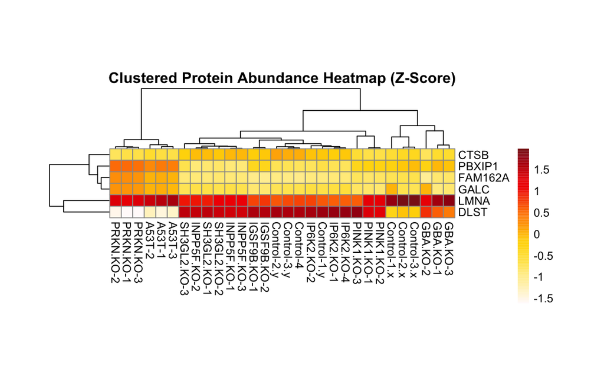

```r
plot_clustered_protein_heatmap_zscore(
  data = df,
  proteins = genelist, # Example protein names
  sample_patterns = c("Control", "A53T","GBA.KO","PINK1.KO","PRKN.KO","INPP5F.KO","IGSF9B.KO", "SH3GL2.KO","IP6K2.KO"),
  colors = c("snow", "lightgoldenrod1", "gold1", "darkorange1", "red2", "firebrick4"),
  scale_values = c(-2,-1.5,-1,-0.5, 0, 1,2,2.5), # Adjust based on your data range
  group_means = TRUE, # Set to FALSE if you want individual samples
  cell_width = 10, # Control column width
  cell_height = 10 # Control row height
)
```

The data is still not aligned try an R combate package